# **PROYECTO 2 - Modelos de clasificación supervisada para evaluar la calidad de un automovil**

## ***Análisis y exploración de datos***

```python
from sklearn.linear_model import LinearRegression, SGDRegressor, Ridge, Lasso
import matplotlib.pyplot as plt
import seaborn as sns
import pandas as pd
import numpy as np
import random
from sklearn.preprocessing import PolynomialFeatures, StandardScaler, OneHotEncoder
from sklearn.model_selection import train_test_split
from sklearn.pipeline import Pipeline
from sklearn.metrics import mean_absolute_error, mean_squared_error
from sklearn.impute import SimpleImputer
from sklearn.feature_selection import SelectPercentile, chi2
from sklearn.compose import ColumnTransformer
```

Se carga la base de datos descargada, esta base de datos está como csv; sin embargo, se tiene con *.data*.

```python
#Cargar el dataframe al archivo
data = pd.read_csv('car.data', header=None)

#En el momento de visualizar los datos, se encuentra que no tiene columnas nombradas, por tal motivo se asignan las columnas
data.columns = ['buying', 'maint', 'doors', 'persons', 'lug_boot', 'safety', 'type']

data
```

|  | buying | maint | doors | persons | lug_boot | safety | type |
| --- | --- | --- | --- | --- | --- | --- | --- |
| 0 | vhigh | vhigh | 2 | 2 | small | low | unacc |
| 1 | vhigh | vhigh | 2 | 2 | small | med | unacc |
| 2 | vhigh | vhigh | 2 | 2 | small | high | unacc |
| 3 | vhigh | vhigh | 2 | 2 | med | low | unacc |
| 4 | vhigh | vhigh | 2 | 2 | med | med | unacc |
| ... | ... | ... | ... | ... | ... | ... | ... |
| 1723 | low | low | 5more | more | med | med | good |
| 1724 | low | low | 5more | more | med | high | vgood |
| 1725 | low | low | 5more | more | big | low | unacc |
| 1726 | low | low | 5more | more | big | med | good |
| 1727 | low | low | 5more | more | big | high | vgood |

1728 rows × 7 columns

La variable objetivo debe de ser la columna "class" sin embargo, se decidió (pues *class* es un template de código de python) ponerle a la columna "type"

```python
#Se llama el dataframe con .info para revisar el Dtype de cada una de las variables
data.info()
```

```
<class 'pandas.core.frame.DataFrame'>
RangeIndex: 1728 entries, 0 to 1727
Data columns (total 7 columns):
 #   Column    Non-Null Count  Dtype
---  ------    --------------  -----
 0   buying    1728 non-null   object
 1   maint     1728 non-null   object
 2   doors     1728 non-null   object
 3   persons   1728 non-null   object
 4   lug_boot  1728 non-null   object
 5   safety    1728 non-null   object
 6   type      1728 non-null   object
dtypes: object(7)
memory usage: 94.6+ KB
```

```python
data["type"].describe()
```

```
count      1728
unique        4
top       unacc
freq       1210
Name: type, dtype: object
```

```python
data["type"].value_counts()
```

```
type
unacc    1210
acc       384
good       69
vgood      65
Name: count, dtype: int64
```

```python
#Determinar la cantidad de variables y registros
num_variables = len(data.columns)
num_registros = len(data)
print(f'Número de variables: {num_variables}')
print(f'Número de registros: {num_registros}')
```

```
Número de variables: 7
Número de registros: 1728
```

Ya se sabe que todas las variables son Dtype *objeto*, sin embargo, se decide identificar que columnas son numéricas y cuales cualitativas para mostrar la diferencia cuando se trata de ajustar el modelo con variables binarias.

```python
# Identificar variables numéricas y cualitativas
variables_numericas = data.select_dtypes(include=['int64', 'float64']).columns.tolist()
variables_cualitativas = data.select_dtypes(include=['object']).columns.tolist()
print(f'Variables numéricas: {variables_numericas}')
print(f'Variables cualitativas: {variables_cualitativas}')
```

```
Variables numéricas: []
Variables cualitativas: ['buying', 'maint', 'doors', 'persons', 'lug_boot', 'safety', 'type']
```

Se decide agregar como insumo un gráfico de distribución de las categorías dentro de la variable *type*

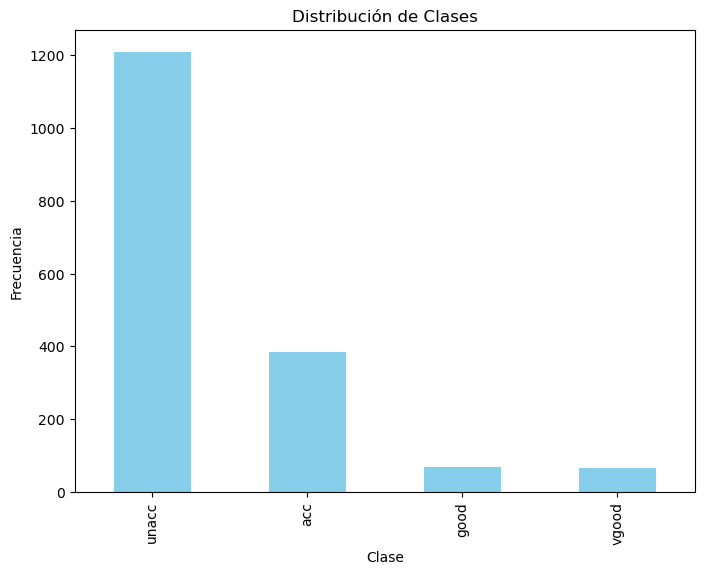

```python
import matplotlib.pyplot as plt

plt.figure(figsize=(8, 6))
data['type'].value_counts().plot(kind='bar', color='skyblue')
plt.xlabel('Clase')
plt.ylabel('Frecuencia')
plt.title('Distribución de Clases')
plt.show()
```

Se pasa a hacer una visualización gráfica de la distribución de la columna *type* con el resto de las variables

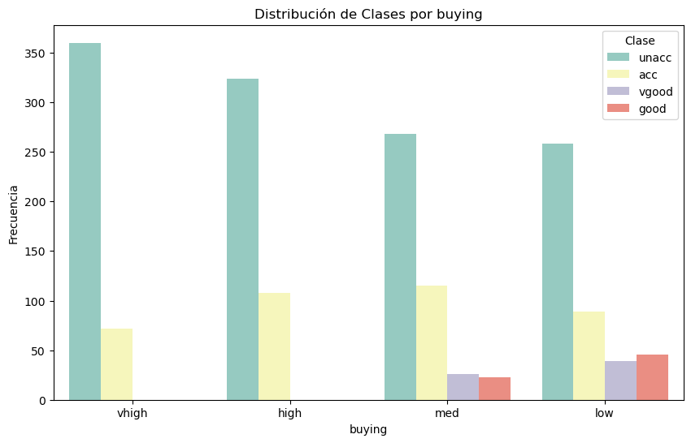

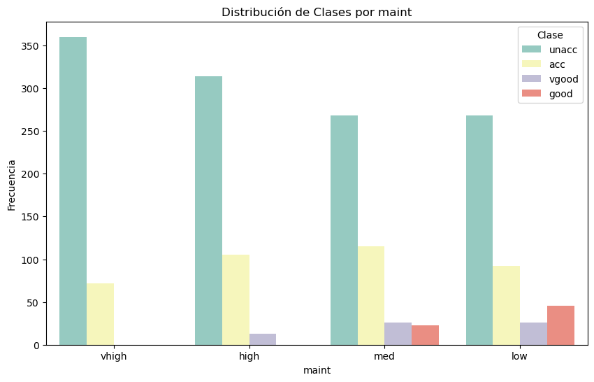

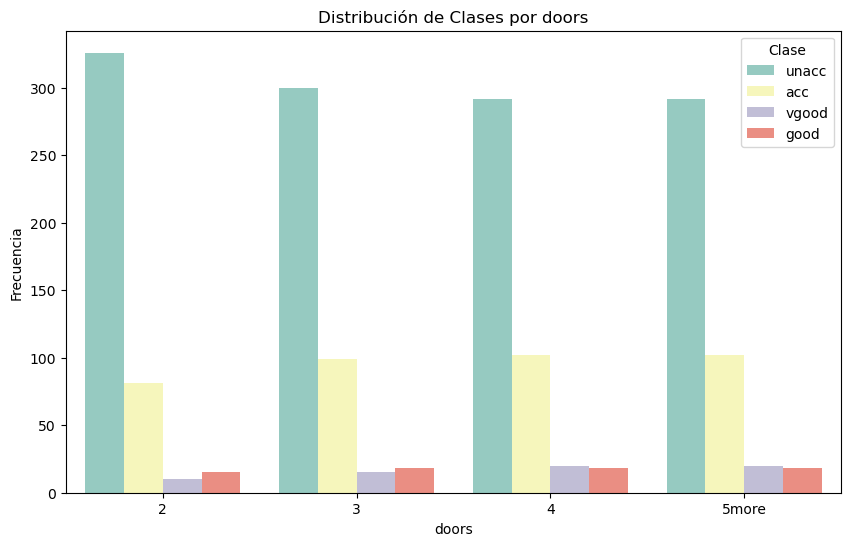

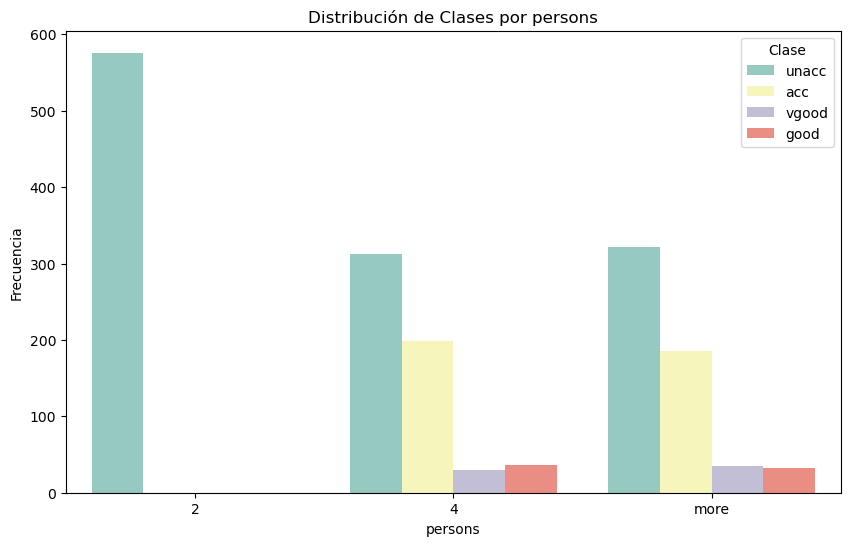

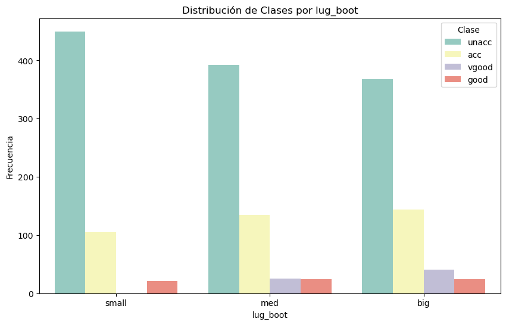

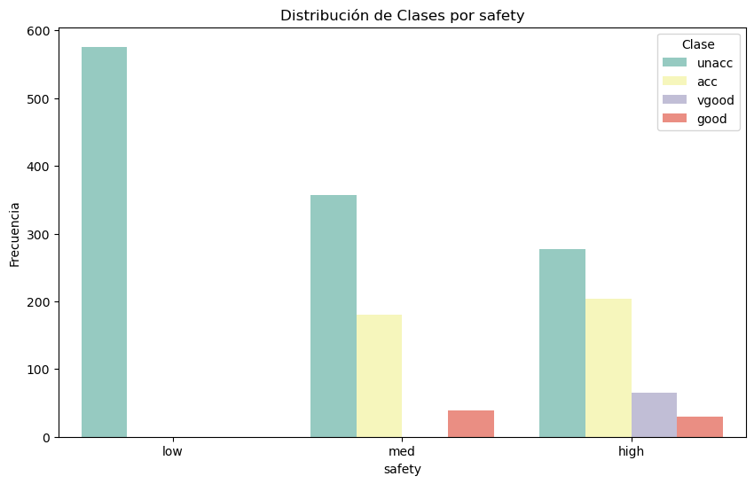

```python
import matplotlib.pyplot as plt
import seaborn as sns

#Obtener una lista de las variables categóricas
variables_categoricas = data.columns[data.dtypes == 'object'].drop('type')

#Crear gráficos de barras para cada variable categórica
for variable in variables_categoricas:
    plt.figure(figsize=(10, 6))
    sns.countplot(x=variable, hue='type', data=data, palette='Set3')
    plt.xlabel(variable)
    plt.ylabel('Frecuencia')
    plt.title(f'Distribución de Clases por {variable}')
    plt.legend(title='Clase', loc='upper right')
    plt.show()
```

## ***Preparación de datos para entrenar el modelo***

```python
#Dividir los datos en testeo y prueba, en donde nuestra x serán todas las demás columnas
#y la y será la columna objetivo type

xtrain, xtest, ytrain, ytest = train_test_split(
    data.drop(columns=['type']), data['type'], test_size=0.3, random_state=0)
```

```python
ytrain.value_counts()
```

```
type
unacc    847
acc      269
vgood     49
good      44
Name: count, dtype: int64
```

```python
ytest.value_counts()
```

```
type
unacc    363
acc      115
good      25
vgood     16
Name: count, dtype: int64
```

## ***Modelo 1***

Como se decidió, para este primer modelo, dejar los datos categóricos, debemos de entrenar el modelo para que entienda que los datos son categóricos. Por este motivo, se hace una lista *categorical_features* que contenga todas las columnas de nuestra variable x

De igual forma, se da la posibiliad de que identifique variables numéricas, por tal motivo, en la lista *numerical_features* se busca seleccionar las columnas que tengan Dtype *float64* y *int64*

```python
from sklearn.linear_model import LogisticRegression
from sklearn.preprocessing import StandardScaler
from sklearn.pipeline import Pipeline

categorical_features = ['buying', 'maint', 'doors', 'persons', 'lug_boot', 'safety']

numerical_features = data.select_dtypes(include=['float64', 'int64']).columns.tolist()

numerical_transformer = Pipeline(steps=[
    ('scaler', StandardScaler())
])

categorical_transformer = Pipeline(steps=[
    ('encoder', OneHotEncoder(handle_unknown='ignore')),
    ('selector', SelectPercentile(chi2, percentile=50))
])

preprocessor = ColumnTransformer(
    transformers=[
        ('num', numerical_transformer, numerical_features),
        ('cat', categorical_transformer, categorical_features)
    ])

classifier = Pipeline(steps=[
    ('preprocessor', preprocessor),
    ('classifier', LogisticRegression())
])

classifier.fit(xtrain, ytrain)
```

```
Pipeline(steps=[('preprocessor',
                 ColumnTransformer(transformers=[('num',
                                                  Pipeline(steps=[('scaler',
                                                                   StandardScaler())]),
                                                  []),
                                                 ('cat',
                                                  Pipeline(steps=[('encoder',
                                                                   OneHotEncoder(handle_unknown='ignore')),
                                                                  ('selector',
                                                                   SelectPercentile(percentile=50,
                                                                                    score_func=<function chi2 at 0x0000023272020040>))]),
                                                  ['buying', 'maint', 'doors',
                                                   'persons', 'lug_boot',
                                                   'safety'])])),
                ('classifier', LogisticRegression())])
```

```python
from sklearn.metrics import confusion_matrix

ypred = classifier.predict(xtest)
conf_matrix = confusion_matrix(ytest, ypred)

print ("Confusion Matrix: \n", conf_matrix)
```

```
Confusion Matrix:
 [[ 90   4  19   2]
 [ 17   4   0   4]
 [ 33   0 330   0]
 [  9   0   0   7]]
```

Gracias a esta matriz de confusión, podemos ver que el modelo per se es bueno para la predicción de las variables. Sin embargo, en la fila 2, solo está prediciendo bien 4 datos y 21 mal. Vamos a graficar para verlo mejor.

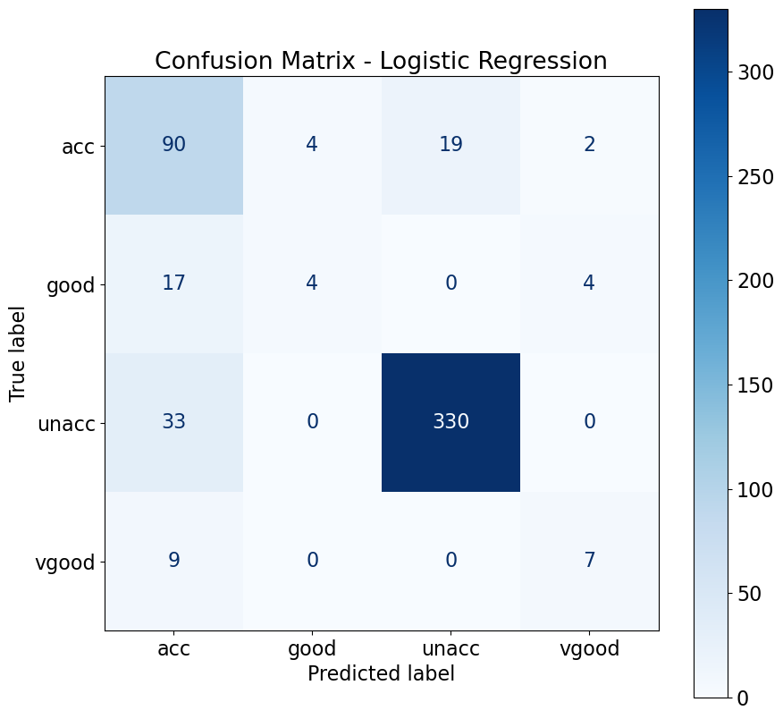

```python
from sklearn.metrics import confusion_matrix, ConfusionMatrixDisplay
plt.rcParams.update({'font.size': 16})
fig, axes = plt.subplots(figsize=(10, 10))
disp = ConfusionMatrixDisplay.from_estimator(classifier,
                                             xtest,
                                             ytest,
                                             display_labels=classifier.classes_,
                                             cmap=plt.cm.Blues,
                                             ax=axes
                                             )
disp.ax_.set_title('Confusion Matrix - Logistic Regression')
```

```python
from sklearn.metrics import classification_report
target_names = ['acc', 'good', 'unacc', 'vgood']
print(classification_report(ytest, ypred, target_names=target_names))
```

```
              precision    recall  f1-score   support

         acc       0.60      0.78      0.68       115
        good       0.50      0.16      0.24        25
       unacc       0.95      0.91      0.93       363
       vgood       0.54      0.44      0.48        16

    accuracy                           0.83       519
   macro avg       0.65      0.57      0.58       519
weighted avg       0.84      0.83      0.83       519
```

Este modelo tiene un porcentaje de exactitud de 83%, este dato es la proporción de predicciones correctas en el modelo de manera general, lo que indica que el modelo clasifica correctamente el 83% de las instancias en el conjunto de prueba.

Nuestro modelo parece tener un buen rendimiento en general, con una precisión y un F1-score altos para la clase "unacc", que es la clase mayoritaria. Sin embargo, se considera que se puede mejorar la precisión y el recall para las clases minoritarias "good" y "vgood".

```python
y_predicted = classifier.predict(xtest)
y_predicted[:5]
```

```
array(['unacc', 'unacc', 'unacc', 'unacc', 'unacc'], dtype=object)
```

```python
import pandas as pd

class_counts = pd.Series(y_predicted).value_counts()
print(class_counts)
```

```
unacc    349
acc      149
vgood     13
good       8
Name: count, dtype: int64
```

```python
y_prob = classifier.predict_proba(xtest)
y_prob[:5]
```

```
array([[4.10250735e-01, 3.10875845e-02, 5.57093320e-01, 1.56836024e-03],
       [2.94292102e-01, 2.20063192e-03, 7.03350232e-01, 1.57033435e-04],
       [5.18523063e-06, 4.93096222e-07, 9.99993741e-01, 5.80433002e-07],
       [1.12674554e-06, 2.06737352e-08, 9.99998835e-01, 1.78877707e-08],
       [1.13724322e-05, 8.73036511e-06, 9.99972507e-01, 7.38973780e-06]])
```

### ***ROC***

```python
def make_meshgrid(X, y, step=.02):
    x = X.iloc[:,0]
    y = X.iloc[:,1]
    x_min, x_max = x.min() - 1, x.max() + 1
    y_min, y_max = y.min() - 1, y.max() + 1
    xx, yy = np.meshgrid(np.arange(x_min, x_max, step), np.arange(y_min, y_max, step))
    return xx, yy

def plot_contours(ax, clf, X, y, **params):
    xx, yy = make_meshgrid(X, y)
    Z = clf.predict(np.c_[xx.ravel(), yy.ravel()])

    Z = Z.reshape(xx.shape)
    ax.scatter(X.iloc[:,0], X.iloc[:,1], c=y.values, cmap=plt.cm.coolwarm, s=100, edgecolors='k')
    ax.set_ylabel(X.columns[1])
    ax.set_xlabel(X.columns[0])
    ax.set_title(clf.__class__.__name__)
    plt.grid()
    out = ax.contourf(xx, yy, Z, **params)
    return out
```

```python
from sklearn.metrics import roc_curve, auc
from sklearn.preprocessing import label_binarize

y_score = classifier.predict_proba(xtest)

y_bin = label_binarize(ytest, classes=['acc', 'good', 'no acc', 'vgood'])

# Calcula la curva ROC para cada clase
fpr = dict()
tpr = dict()
roc_auc = dict()
for i in range(4):
    fpr[i], tpr[i], _ = roc_curve(y_bin[:, i], y_score[:, i])
    roc_auc[i] = auc(fpr[i], tpr[i])
```

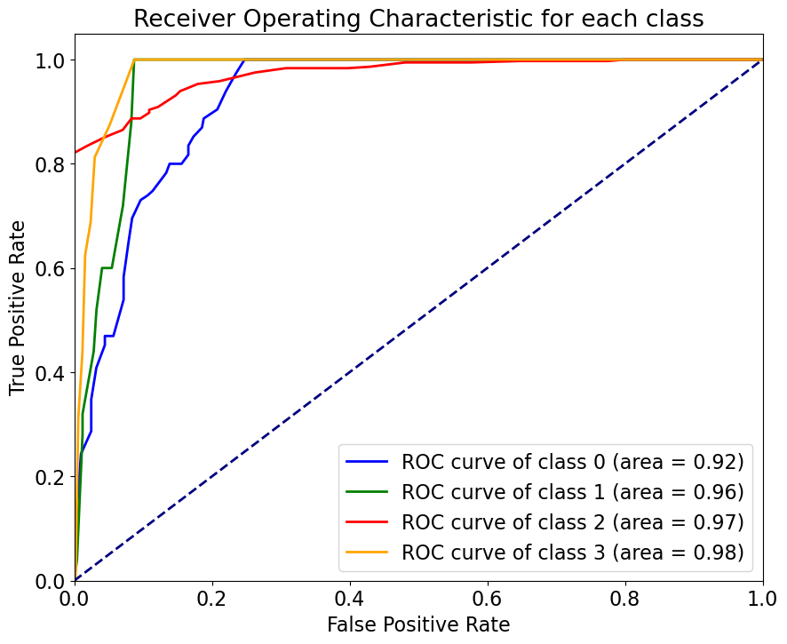

```python
from sklearn.metrics import roc_curve, auc
from sklearn.preprocessing import label_binarize
import matplotlib.pyplot as plt

#Se binariza los labels de la columna type
y_bin = label_binarize(ytest, classes=['acc', 'good', 'unacc', 'vgood'])

#Se calcula la curva ROC para cada type
fpr = dict()
tpr = dict()
roc_auc = dict()
for i in range(4):
    fpr[i], tpr[i], _ = roc_curve(y_bin[:, i], y_score[:, i])
    roc_auc[i] = auc(fpr[i], tpr[i])

#Gráfica
plt.figure(figsize=(10, 8))
colors = ['blue', 'green', 'red', 'orange']
for i, color in zip(range(4), colors):
    plt.plot(fpr[i], tpr[i], color=color, lw=2,
             label='ROC curve of class {0} (area = {1:0.2f})'
             ''.format(i, roc_auc[i]))

plt.plot([0, 1], [0, 1], color='navy', lw=2, linestyle='--')
plt.xlim([0.0, 1.0])
plt.ylim([0.0, 1.05])
plt.xlabel('False Positive Rate')
plt.ylabel('True Positive Rate')
plt.title('Receiver Operating Characteristic for each class')
plt.legend(loc="lower right")
plt.show()
```

### ***Proporción de los datos en conjuntos de entrenamiento y prueba***

```python
from sklearn.model_selection import train_test_split

xtrain, xtest, ytrain, ytest = train_test_split(
    data.drop(columns=['type']), data['type'], test_size=0.3, random_state=0, stratify=data['type'])

print("Proporción de clases en ytrain:")
print(ytrain.value_counts(normalize=True))
print("\nProporción de clases en ytest:")
print(ytest.value_counts(normalize=True))
```

```
Proporción de clases en ytrain:
type
unacc    0.700579
acc      0.222498
good     0.039702
vgood    0.037221
Name: proportion, dtype: float64

Proporción de clases en ytest:
type
unacc    0.699422
acc      0.221580
good     0.040462
vgood    0.038536
Name: proportion, dtype: float64
```

## ***MODELO 2***

Se intentará mejorar la precisión y el recall para las clases minoritarias *good* y *vgood*.

Primero lo que se hará es hacer una copia de nuestro dataframe original *data* y se empezará a usar el nuevo dtaframe *data_copy*. Se opota por hacer esto para no perder los datos base originales y no perder lo que se hizo en el primer modelo.

```python
from sklearn.preprocessing import OneHotEncoder

data_copy = data.copy()

#Convertir variables categóricas en variables numéricas binarias
encoder = OneHotEncoder()
data_encoded = encoder.fit_transform(data_copy[['buying', 'maint', 'doors', 'persons', 'lug_boot', 'safety']])

#Convertir a DataFrame y unir con la copia del DataFrame original
data_encoded_df = pd.DataFrame(data_encoded.toarray(), columns=encoder.get_feature_names_out(['buying', 'maint', 'doors', 'persons', 'lug_boot', 'safety']))
data_copy = pd.concat([data_copy, data_encoded_df], axis=1)

#Eliminar las columnas originales
data_copy.drop(columns=['buying', 'maint', 'doors', 'persons', 'lug_boot', 'safety'], inplace=True)
```

Con esta nueva limpieza que se hace en el dataframe *data_copy* se debe de ajustar el codificador de los datos de entrada, por eso se usa el método *fit_transform* el cual transforma los datos categóricos en representaciones numéricas.

En una mirada más profunda, lo que se hace es que se ajusta y se transforma el nuevo dataframe (*data_copy*) seleccionando solamente las columnas especificadas para la transformación.

Lo que nos ayuda a hacer este proceso es que, en cada una de las columnas se convierta las variables categóricas a variables binarias (0 y 1) en columnas separadas. Lo que se busca con esto es evitar que nuestro modelo interprete erroneamente las variables.

```python
data_copy.describe()
```

|  | buying_high | buying_low | buying_med | buying_vhigh | maint_high | maint_low | maint_med | maint_vhigh | doors_2 | doors_3 | ... | doors_5more | persons_2 | persons_4 | persons_more | lug_boot_big | lug_boot_med | lug_boot_small | safety_high | safety_low | safety_med |
| --- | --- | --- | --- | --- | --- | --- | --- | --- | --- | --- | --- | --- | --- | --- | --- | --- | --- | --- | --- | --- | --- |
| count | 1728.000000 | 1728.000000 | 1728.000000 | 1728.000000 | 1728.000000 | 1728.000000 | 1728.000000 | 1728.000000 | 1728.000000 | 1728.000000 | ... | 1728.000000 | 1728.000000 | 1728.000000 | 1728.000000 | 1728.000000 | 1728.000000 | 1728.000000 | 1728.000000 | 1728.000000 | 1728.000000 |
| mean | 0.250000 | 0.250000 | 0.250000 | 0.250000 | 0.250000 | 0.250000 | 0.250000 | 0.250000 | 0.250000 | 0.250000 | ... | 0.250000 | 0.333333 | 0.333333 | 0.333333 | 0.333333 | 0.333333 | 0.333333 | 0.333333 | 0.333333 | 0.333333 |
| std | 0.433138 | 0.433138 | 0.433138 | 0.433138 | 0.433138 | 0.433138 | 0.433138 | 0.433138 | 0.433138 | 0.433138 | ... | 0.433138 | 0.471541 | 0.471541 | 0.471541 | 0.471541 | 0.471541 | 0.471541 | 0.471541 | 0.471541 | 0.471541 |
| min | 0.000000 | 0.000000 | 0.000000 | 0.000000 | 0.000000 | 0.000000 | 0.000000 | 0.000000 | 0.000000 | 0.000000 | ... | 0.000000 | 0.000000 | 0.000000 | 0.000000 | 0.000000 | 0.000000 | 0.000000 | 0.000000 | 0.000000 | 0.000000 |
| 25% | 0.000000 | 0.000000 | 0.000000 | 0.000000 | 0.000000 | 0.000000 | 0.000000 | 0.000000 | 0.000000 | 0.000000 | ... | 0.000000 | 0.000000 | 0.000000 | 0.000000 | 0.000000 | 0.000000 | 0.000000 | 0.000000 | 0.000000 | 0.000000 |
| 50% | 0.000000 | 0.000000 | 0.000000 | 0.000000 | 0.000000 | 0.000000 | 0.000000 | 0.000000 | 0.000000 | 0.000000 | ... | 0.000000 | 0.000000 | 0.000000 | 0.000000 | 0.000000 | 0.000000 | 0.000000 | 0.000000 | 0.000000 | 0.000000 |
| 75% | 0.250000 | 0.250000 | 0.250000 | 0.250000 | 0.250000 | 0.250000 | 0.250000 | 0.250000 | 0.250000 | 0.250000 | ... | 0.250000 | 1.000000 | 1.000000 | 1.000000 | 1.000000 | 1.000000 | 1.000000 | 1.000000 | 1.000000 | 1.000000 |
| max | 1.000000 | 1.000000 | 1.000000 | 1.000000 | 1.000000 | 1.000000 | 1.000000 | 1.000000 | 1.000000 | 1.000000 | ... | 1.000000 | 1.000000 | 1.000000 | 1.000000 | 1.000000 | 1.000000 | 1.000000 | 1.000000 | 1.000000 | 1.000000 |

8 rows × 21 columns

```python
data_copy.info()
```

```
<class 'pandas.core.frame.DataFrame'>
RangeIndex: 1728 entries, 0 to 1727
Data columns (total 22 columns):
 #   Column          Non-Null Count  Dtype
---  ------          --------------  -----
 0   type            1728 non-null   object
 1   buying_high     1728 non-null   float64
 2   buying_low      1728 non-null   float64
 3   buying_med      1728 non-null   float64
 4   buying_vhigh    1728 non-null   float64
 5   maint_high      1728 non-null   float64
 6   maint_low       1728 non-null   float64
 7   maint_med       1728 non-null   float64
 8   maint_vhigh     1728 non-null   float64
 9   doors_2         1728 non-null   float64
 10  doors_3         1728 non-null   float64
 11  doors_4         1728 non-null   float64
 12  doors_5more     1728 non-null   float64
 13  persons_2       1728 non-null   float64
 14  persons_4       1728 non-null   float64
 15  persons_more    1728 non-null   float64
 16  lug_boot_big    1728 non-null   float64
 17  lug_boot_med    1728 non-null   float64
 18  lug_boot_small  1728 non-null   float64
 19  safety_high     1728 non-null   float64
 20  safety_low      1728 non-null   float64
 21  safety_med      1728 non-null   float64
dtypes: float64(21), object(1)
memory usage: 297.1+ KB
```

Podemos ver que se dividieron las variables por cada una de las categorías que tenía. Es decir, en la variable *buying* teníamos categoría *vhigh*, *high*, *low* y *med*; y ahora tenemos 4 variables nuevas de buying.

Veamos como se comportan los valores:

```python
#Para cada columna queremos que muestre los value_counts() agrupados por la variable objetivo 'type'
for column in data_copy.columns:
    if column != 'type':  #Evita mostrar los value_counts() de la variable objetivo
        print(f"\nValue counts for {column}:")
        print(data_copy.groupby('type')[column].value_counts())
```

```
Value counts for buying_high:
type   buying_high
acc    0.0            276
       1.0            108
good   0.0             69
unacc  0.0            886
       1.0            324
vgood  0.0             65
Name: count, dtype: int64

Value counts for buying_low:
type   buying_low
acc    0.0           295
       1.0            89
good   1.0            46
       0.0            23
unacc  0.0           952
       1.0           258
vgood  1.0            39
       0.0            26
Name: count, dtype: int64

Value counts for buying_med:
type   buying_med
acc    0.0           269
       1.0           115
good   0.0            46
       1.0            23
unacc  0.0           942
       1.0           268
vgood  0.0            39
       1.0            26
Name: count, dtype: int64

Value counts for buying_vhigh:
type   buying_vhigh
acc    0.0             312
       1.0              72
good   0.0              69
unacc  0.0             850
```

[output cut: 180 more lines]

```
unacc  0.0           634
       1.0           576
vgood  0.0            65
Name: count, dtype: int64

Value counts for safety_med:
type   safety_med
acc    0.0           204
       1.0           180
good   1.0            39
       0.0            30
unacc  0.0           853
       1.0           357
vgood  0.0            65
Name: count, dtype: int64
```

En el ejemplo proporcionado, se muestra la relación entre la variable categórica *buying_low* y la variable objetivo *type*. Para cada categoría de *type*, se presenta el recuento de instancias en las que *buying_low* tiene el valor ***1*** y ***0***.

Por ejemplo, en la fila correspondiente a la categoría *acc (aceptable)*, los valores ***0.0*** y ***1.0*** representan la presencia o ausencia de la categoría *buying_low* en las instancias de *type* igual a *acc*. Si una instancia tiene la categoría *acc* y *buying_low*, se registra como "1", de lo contrario, se registra como "0".

### **MODELACIÓN**

```python
#Dividir los datos en testeo y prueba, en donde nuestra x serán todas las demás columnas
#y la y será la columna objetivo type

x_train, x_test, y_train, y_test = train_test_split(
    data_copy.drop(columns=['type']), data_copy['type'], test_size=0.3, random_state=0)
```

```python
from sklearn.linear_model import LogisticRegression
from sklearn.preprocessing import StandardScaler
from sklearn.pipeline import Pipeline

classifier = Pipeline([('scaler', StandardScaler()),
                       ('logistic Regession', LogisticRegression())])


classifier.fit(x_train, y_train)
```

```
Pipeline(steps=[('scaler', StandardScaler()),
                ('logistic Regession', LogisticRegression())])
```

```python
y_train.value_counts()
```

```
type
unacc    847
acc      269
vgood     49
good      44
Name: count, dtype: int64
```

```python
y_test.value_counts()
```

```
type
unacc    363
acc      115
good      25
vgood     16
Name: count, dtype: int64
```

### **MATRIZ DE CONFUSIÓN**

```python
from sklearn.metrics import confusion_matrix

ypred = classifier.predict(x_test)
conf_matrix = confusion_matrix(y_test, ypred)

print ("Confusion Matrix: \n", conf_matrix)
```

```
Confusion Matrix:
 [[ 95   5  14   1]
 [  6  15   0   4]
 [ 16   0 347   0]
 [  1   0   0  15]]
```

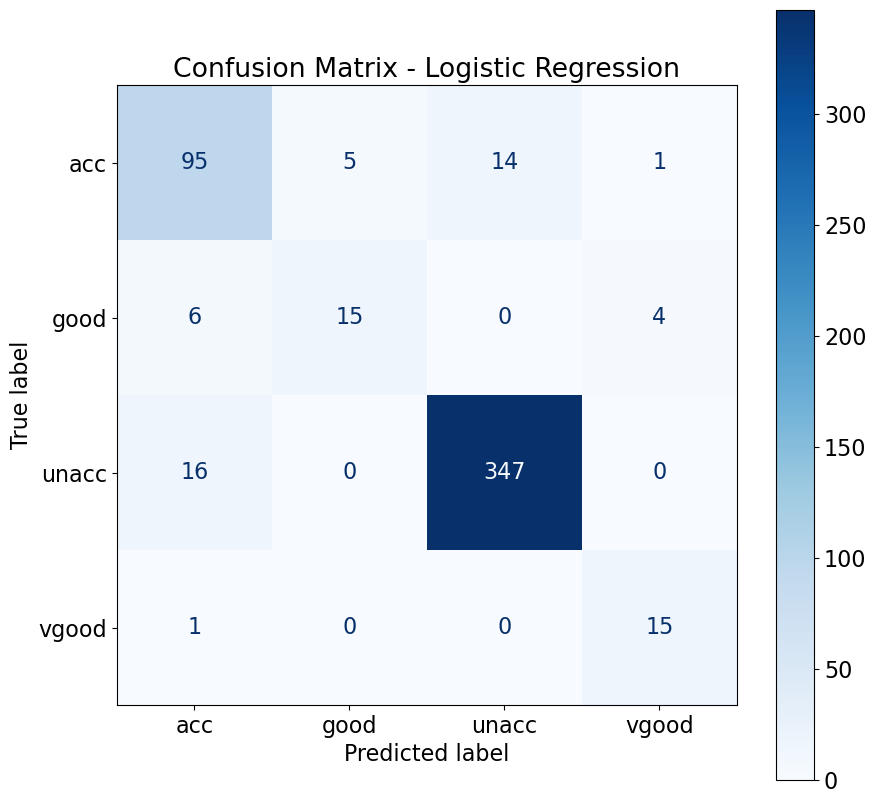

```python
from sklearn.metrics import confusion_matrix, ConfusionMatrixDisplay
plt.rcParams.update({'font.size': 16})
fig, axes = plt.subplots(figsize=(10, 10))
disp = ConfusionMatrixDisplay.from_estimator(classifier,
                                             x_test,
                                             y_test,
                                             display_labels=classifier.classes_,
                                             cmap=plt.cm.Blues,
                                             ax=axes
                                             )
disp.ax_.set_title('Confusion Matrix - Logistic Regression')
```

```python
from sklearn.metrics import classification_report
target_names = ['unacc', 'acc', 'good', 'vgood']
print(classification_report(y_test, ypred, target_names=target_names))
```

```
              precision    recall  f1-score   support

       unacc       0.81      0.83      0.82       115
         acc       0.75      0.60      0.67        25
        good       0.96      0.96      0.96       363
       vgood       0.75      0.94      0.83        16

    accuracy                           0.91       519
   macro avg       0.82      0.83      0.82       519
weighted avg       0.91      0.91      0.91       519
```

Este modelo es tiene un porcentaje de exactitud de 91%, este dato es la proporción de predicciones correctas en el modelo de manera general, lo que indica que el modelo clasifica correctamente el 91% de las instancias en el conjunto de prueba.

[figure not shown]

```python
#Se binariza los labels de la columna type
y_bin = label_binarize(y_test, classes=['acc', 'good', 'unacc', 'vgood'])

#Se calcula la curva ROC para cada type
fpr = dict()
tpr = dict()
roc_auc = dict()
for i in range(4):
    fpr[i], tpr[i], _ = roc_curve(y_bin[:, i], y_score[:, i])
    roc_auc[i] = auc(fpr[i], tpr[i])

#Gráfica
plt.figure(figsize=(10, 8))
colors = ['blue', 'green', 'red', 'orange']
for i, color in zip(range(4), colors):
    plt.plot(fpr[i], tpr[i], color=color, lw=2,
             label='ROC curve of class {0} (area = {1:0.2f})'
             ''.format(i, roc_auc[i]))

plt.plot([0, 1], [0, 1], color='navy', lw=2, linestyle='--')
plt.xlim([0.0, 1.0])
plt.ylim([0.0, 1.05])
plt.xlabel('False Positive Rate')
plt.ylabel('True Positive Rate')
plt.title('Receiver Operating Characteristic for each class')
plt.legend(loc="lower right")
plt.show()
```

# **SMOTEEN**

Se busca la posibilidad de utilizar el método SMOTEENN, esta es un modelo de balanceo de clases que combina dos métodos: SMOTE (Synthetic Minority Over-sampling Technique) y ENN (Edited Nearest Neighbours). Para entender mejor para qué se utiliza este modelo, se debe de entender cada una de las partes del modelo:

1. SMOTE (Técnica de Sobremuestreo Sintético de la Minoría): Este método se usa para aumentar la cantidad de las muestras en las clases minoritarias, de esta forma se generan muestras sintéticas. De esta forma, para cada muestra en la clase minoritaria, se selecciona a los vecinos más cercanos y crea muestras a lo largo de las líneas que conectan la muestra original con sus vecinos.
2. ENN (Edición de Vecinos Más Cercanos): Este método se usa para eliminar muestras de la clase mayoritaria que podrían considerarse como ruido. Es decir que para cada muestra en el conjunto de datos se compara su clase con la clase de sus vecinos más cercanos. Si la muestra y la mayoría de sus vecinos más cercanos no pertenecen a la misma clase, la muestra se elimina.

```python
from imblearn.combine import SMOTEENN
from sklearn.linear_model import LogisticRegression
from sklearn.metrics import roc_curve, auc
from sklearn.preprocessing import label_binarize, LabelEncoder
import matplotlib.pyplot as plt

#Aplicar SMOTEENN para el balanceo de clases
smote_enn = SMOTEENN(random_state=0)
x_resampled, y_resampled = smote_enn.fit_resample(x_train, y_train)

# Ajustar el modelo de regresión logística con los datos balanceados
model = LogisticRegression()
model.fit(x_resampled, y_resampled)
```

```
LogisticRegression()
```

```python
y_resampled.value_counts()
```

```
type
good     847
vgood    847
acc      782
unacc    526
Name: count, dtype: int64
```

## ***REGRESIÓN LOGÍSTICA Y RANDOM FOREST CLASSIFIER***

Ya que se hizo balanceo de clases, es necesario volver a dividir los datos en conjuntos de entrenamiento y prueba

```python
from sklearn.metrics import classification_report
from sklearn.linear_model import LogisticRegression
from sklearn.ensemble import RandomForestClassifier

x_train_resampled, x_test_resampled, y_train_resampled, y_test_resampled = train_test_split(x_resampled,
                                                                                            y_resampled,
                                                                                            test_size=0.3, random_state=0)

#Creación de modelos
modelos = {
    'Regresión Logística': LogisticRegression(),
    'Random Forest': RandomForestClassifier()
}

#Iterar para cada modelo creado
for nombre, modelo in modelos.items():
    modelo.fit(x_train_resampled, y_train_resampled)
    ypred = modelo.predict(x_test_resampled)
    print(f"Reporte de clasificación para {nombre}:")
    print(classification_report(y_test_resampled, ypred))
```

```
Reporte de clasificación para Regresión Logística:
              precision    recall  f1-score   support

         acc       0.97      0.96      0.96       250
        good       0.96      1.00      0.98       270
       unacc       1.00      0.94      0.97       144
       vgood       0.98      1.00      0.99       237

    accuracy                           0.98       901
   macro avg       0.98      0.97      0.98       901
weighted avg       0.98      0.98      0.98       901

Reporte de clasificación para Random Forest:
              precision    recall  f1-score   support

         acc       0.98      0.99      0.99       250
        good       0.99      1.00      1.00       270
       unacc       1.00      0.97      0.98       144
       vgood       1.00      1.00      1.00       237

    accuracy                           0.99       901
   macro avg       0.99      0.99      0.99       901
weighted avg       0.99      0.99      0.99       901
```

Con este primer resultado, podemos ver que subió significativamente los porcentajes, sin emabrgo son casi 100%; lo que podría sugerir que se tiene un sobreajuste.

```python
from sklearn.linear_model import LogisticRegression
from sklearn.preprocessing import StandardScaler
from sklearn.pipeline import Pipeline

classifier = Pipeline([('scaler', StandardScaler()),
                       ('logistic Regession', LogisticRegression())])


classifier.fit(x_train_resampled, y_train_resampled)
```

```
Pipeline(steps=[('scaler', StandardScaler()),
                ('logistic Regession', LogisticRegression())])
```

## ***MATRIZ DE CONFUSIÓN***

```python
from sklearn.metrics import confusion_matrix

ypred_resampled = classifier.predict(x_test_resampled)

conf_matrix_resampled = confusion_matrix(y_test_resampled, ypred_resampled)

print("Confusion Matrix (Resampled Data): \n", conf_matrix_resampled)
```

```
Confusion Matrix (Resampled Data):
 [[245   4   0   1]
 [  0 270   0   0]
 [  4   1 139   0]
 [  0   0   0 237]]
```

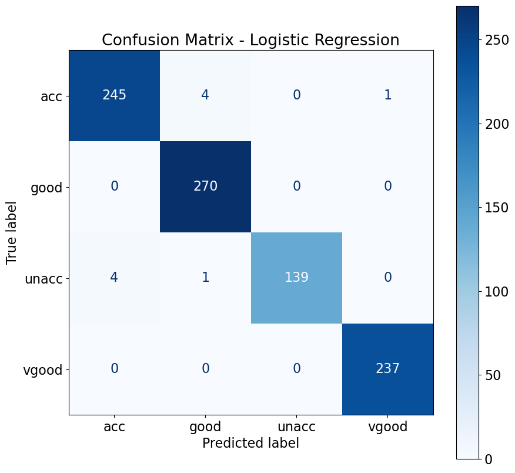

```python
from sklearn.metrics import confusion_matrix, ConfusionMatrixDisplay
plt.rcParams.update({'font.size': 16})
fig, axes = plt.subplots(figsize=(10, 10))
disp = ConfusionMatrixDisplay.from_estimator(classifier,
                                             x_test_resampled,
                                             y_test_resampled,
                                             display_labels=classifier.classes_,
                                             cmap=plt.cm.Blues,
                                             ax=axes
                                             )
disp.ax_.set_title('Confusion Matrix - Logistic Regression')
```

Con la matriz de confusión, se puede ver que el modelo predice casi a la perfección las variables.

```python
from sklearn.metrics import classification_report
target_names = ['unacc', 'acc', 'good', 'vgood']
print(classification_report(y_test_resampled, ypred_resampled, target_names=target_names))
```

```
              precision    recall  f1-score   support

       unacc       0.98      0.98      0.98       250
         acc       0.98      1.00      0.99       270
        good       1.00      0.97      0.98       144
       vgood       1.00      1.00      1.00       237

    accuracy                           0.99       901
   macro avg       0.99      0.99      0.99       901
weighted avg       0.99      0.99      0.99       901
```

## ***ROC Y AUC***

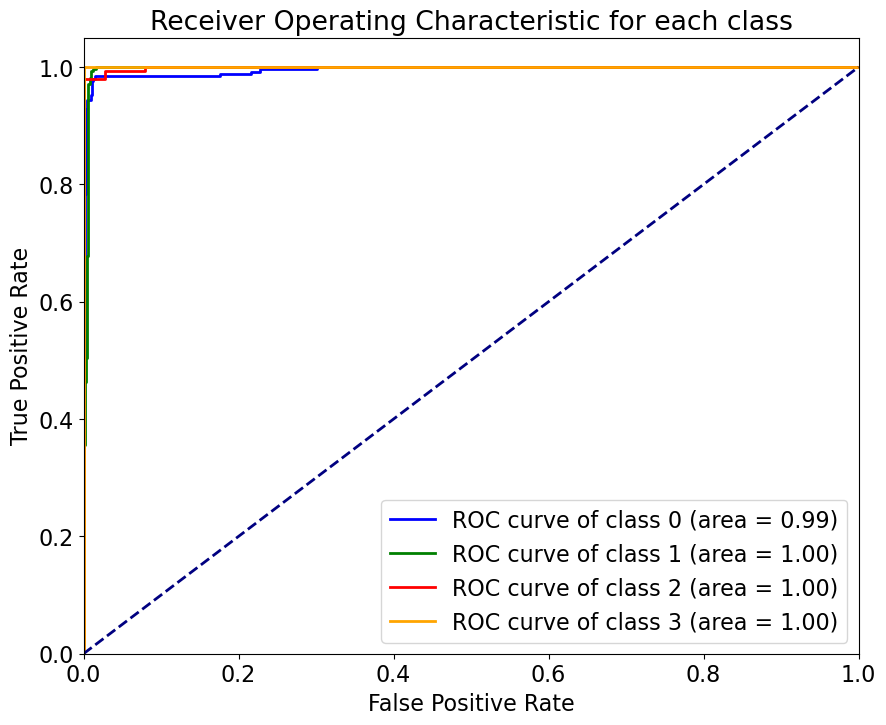

```python
y_score = model.predict_proba(x_test_resampled)

le = LabelEncoder()
y_encoded = le.fit_transform(y_test_resampled)

y_bin = label_binarize(y_encoded, classes=[0, 1, 2, 3])

fpr = dict()
tpr = dict()
roc_auc = dict()
for i in range(4):
    fpr[i], tpr[i], _ = roc_curve(y_bin[:, i], y_score[:, i])
    roc_auc[i] = auc(fpr[i], tpr[i])

plt.figure(figsize=(10, 8))
colors = ['blue', 'green', 'red', 'orange']
for i, color in zip(range(4), colors):
    plt.plot(fpr[i], tpr[i], color=color, lw=2,
             label='ROC curve of class {0} (area = {1:0.2f})'
             ''.format(i, roc_auc[i]))

plt.plot([0, 1], [0, 1], color='navy', lw=2, linestyle='--')
plt.xlim([0.0, 1.0])
plt.ylim([0.0, 1.05])
plt.xlabel('False Positive Rate')
plt.ylabel('True Positive Rate')
plt.title('Receiver Operating Characteristic for each class')
plt.legend(loc="lower right")
plt.show()
```

# **CONCLUSIÓN**

Como conclusión del ejercicio propuesto, se puede ver que si bien, si no se cambian las variables de categóricas a numéricas; el modelo nos da un porcentaje alto. Cuando se ajustan las variables para cambiarlas de categóricas a numéricas binarias, nuestra exactitud del modelo mejora casi en un 10%; sin embargo, cuando se trata de balancear las clases, se puede decir que tendría propensión a un sobreajuste.

De esta forma, al comparar los 3 modelos de clasificación para la evaluación de la calidad de los carros, se observa que el Modelo 3 muestra un rendimiento excepcional en terminos de métircas y resultados, sin embargo, esta propensión a sobreajuste de las variables hace que nos planteemos la duda de si sería bueno usarlo. Siento que, si se decide usar este, podríamos presentarnos con problemas respecto a la capacidad del Modelo 3 de generalizar nuevos datos.

Por lo tanto, se concluye que el Modelo 2 sería la mejor elección para predecir la calidad de los carros, ya que ofrece un buen rendimiento sin sufrir de sobreajuste, lo que lo hace más adecuado para la generalización a nuevos datos en comparación con los otros dos modelos.